# 📊 programandoenR

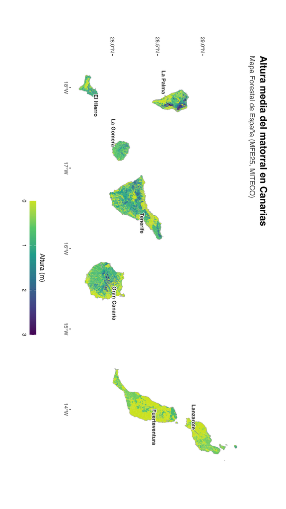

### Altura media del matorral en Canarias

code

analysis

Nov 18, 2026

FV

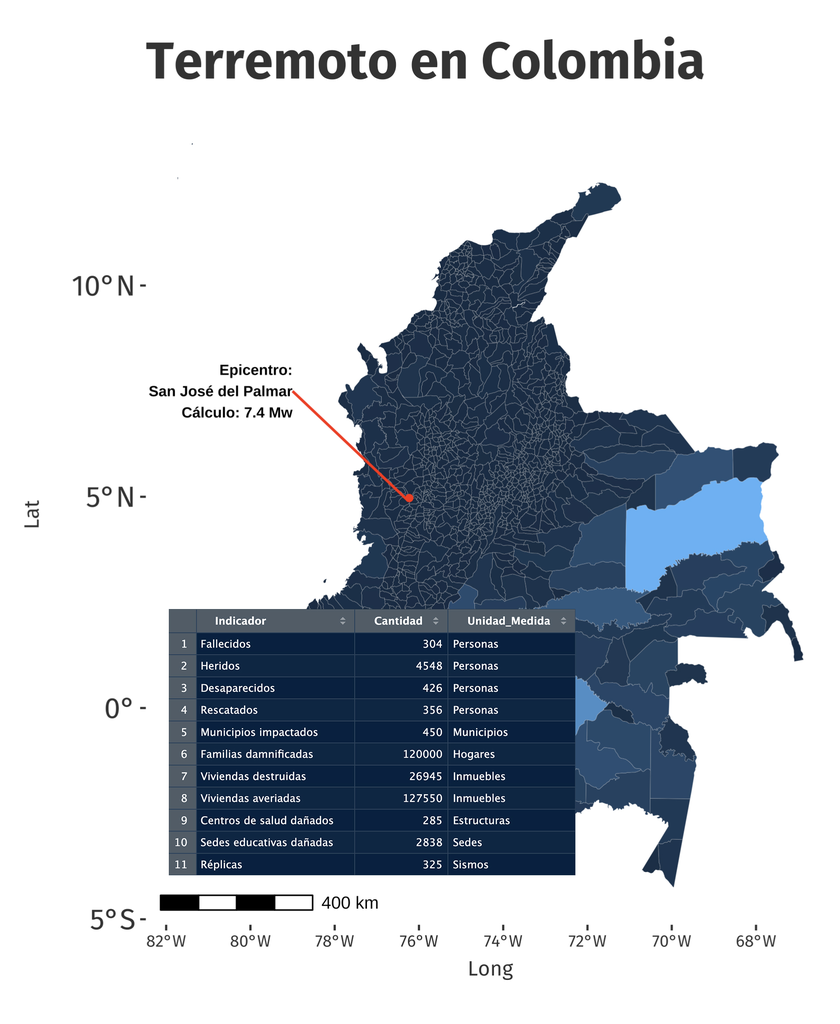

### Terremoto en Colombia

code

analysis

Author: FV

Aug 19, 2026

FV

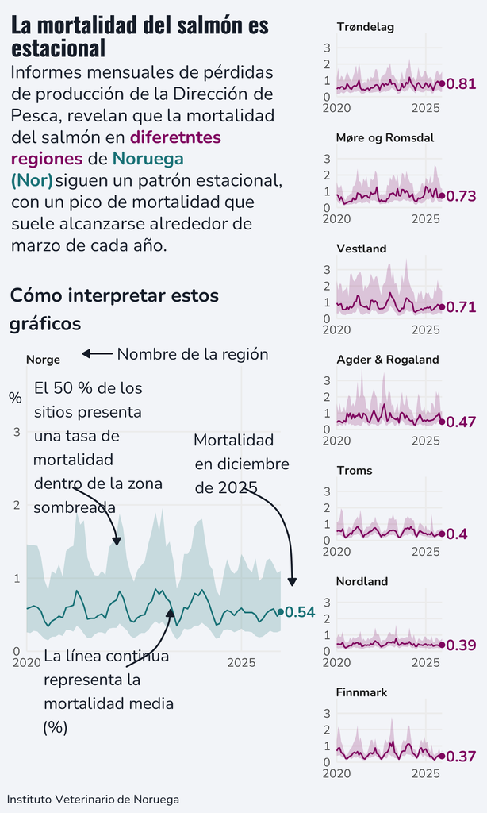

### Informes mensuales de pérdidas de producción en Noruega

code

analysis

Mar 25, 2026

FV

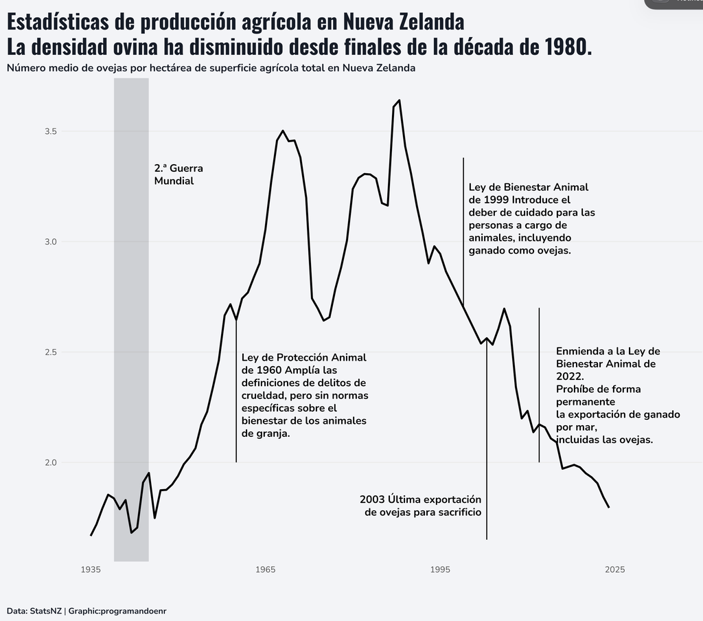

### Estadistícas de producción agrícola en Nueva Zelanda

code

analysis

EN

Feb 25, 2026

FV

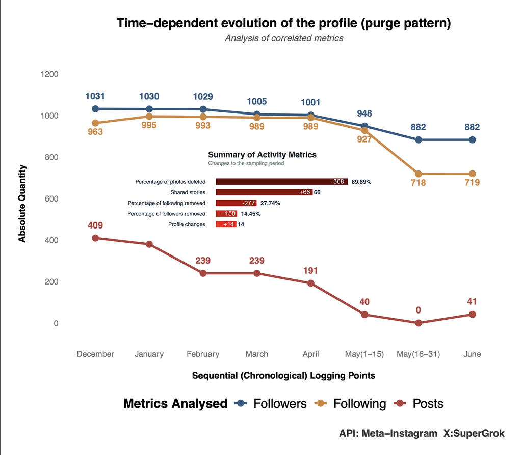

### Social media analysis (using APIs Meta & X)

code

analysis

ES

Dec 31, 2025

FV

[figure not shown]

### Aumento de precios de la gasolina en EE.UU.

code

analysis

Aumento de precios de la gasolina en EE.UU.

Sep 30, 2025

FV

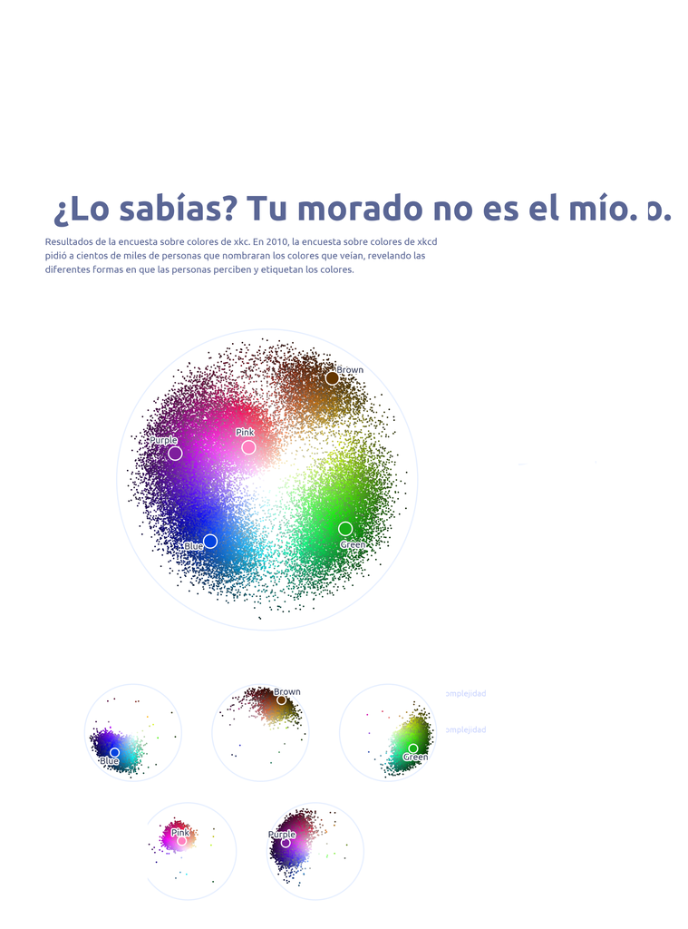

### Percpfión de los colores - Resultados gráficos de encuesta Xkcd

code

analysis

Sep 29, 2025

FV

[figure not shown]

### MAP

code

analysis

map

#Maps

Sep 26, 2025

FV

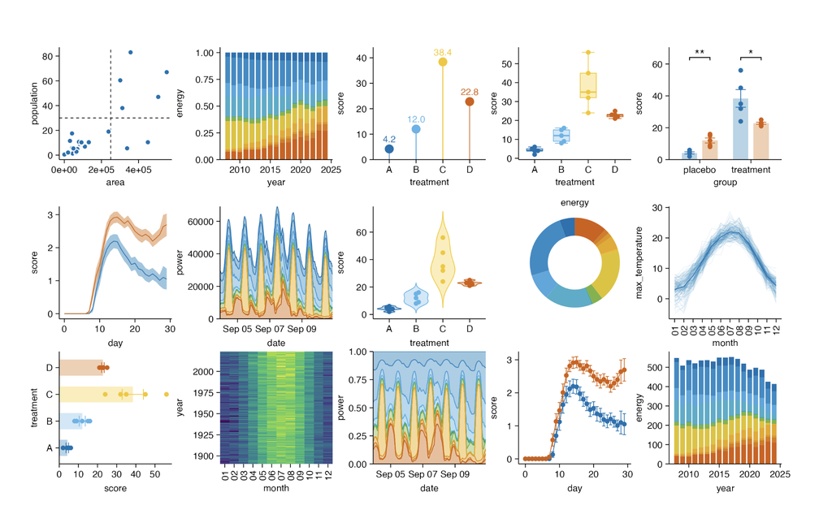

### TIDYPLOTS

code

analysis

TIDYPLOTS

Sep 21, 2025

FV

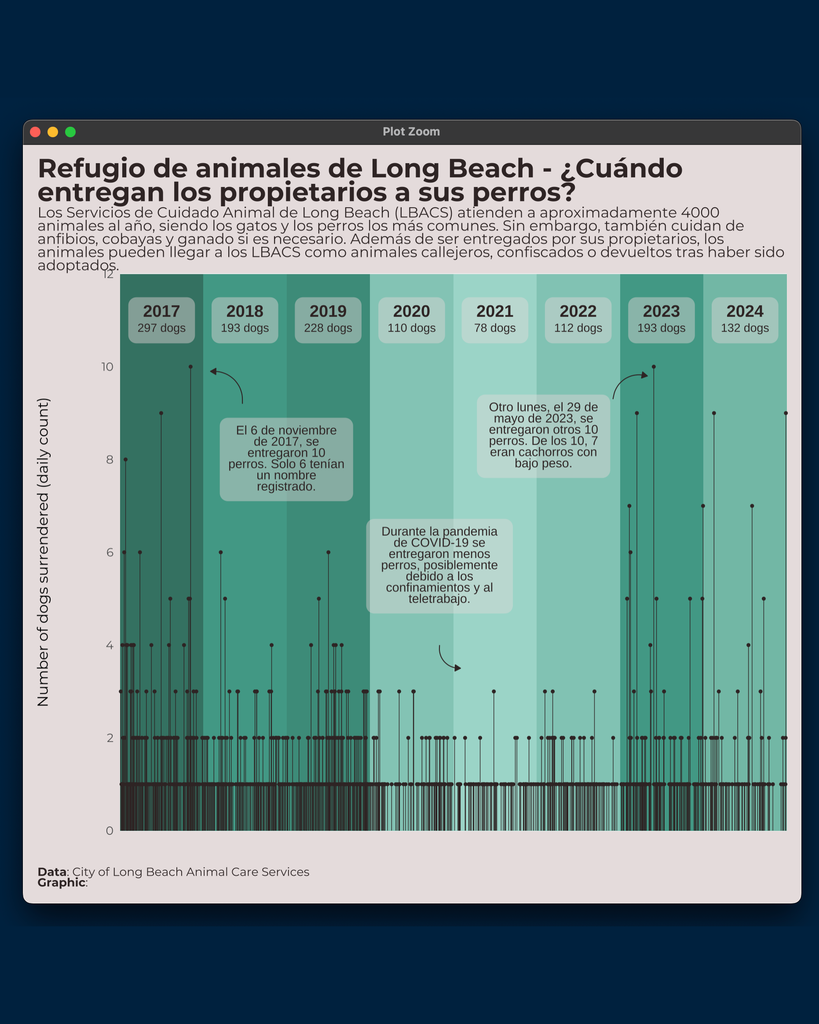

### Refugio de animales de Long Beach

code

analysis

Sep 14, 2025

FV

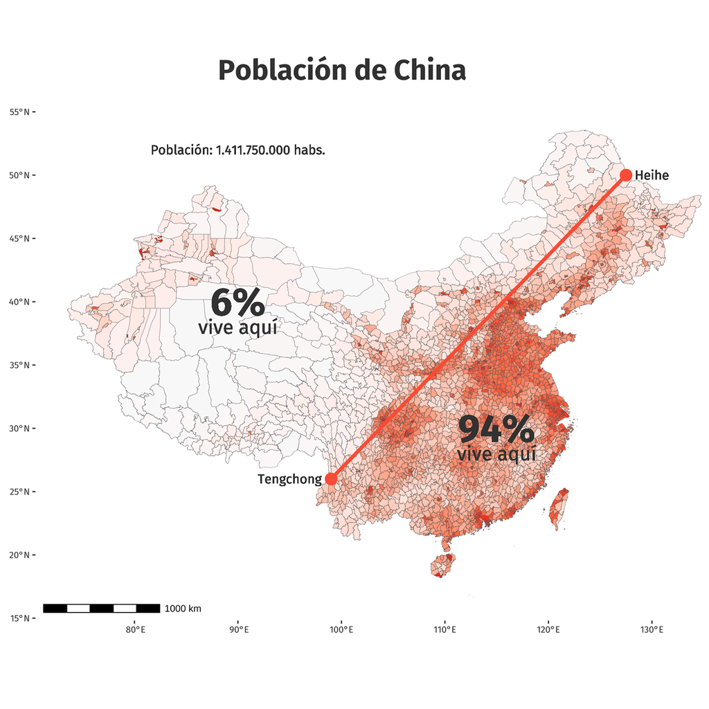

### Población de China

code

map

En este caso trabajando con la librería “mapchina”. Esta librería contiene capas shapefile y datos poblacionales. Trabajando con la función gradiente de colores.

Oct 17, 2024

FV

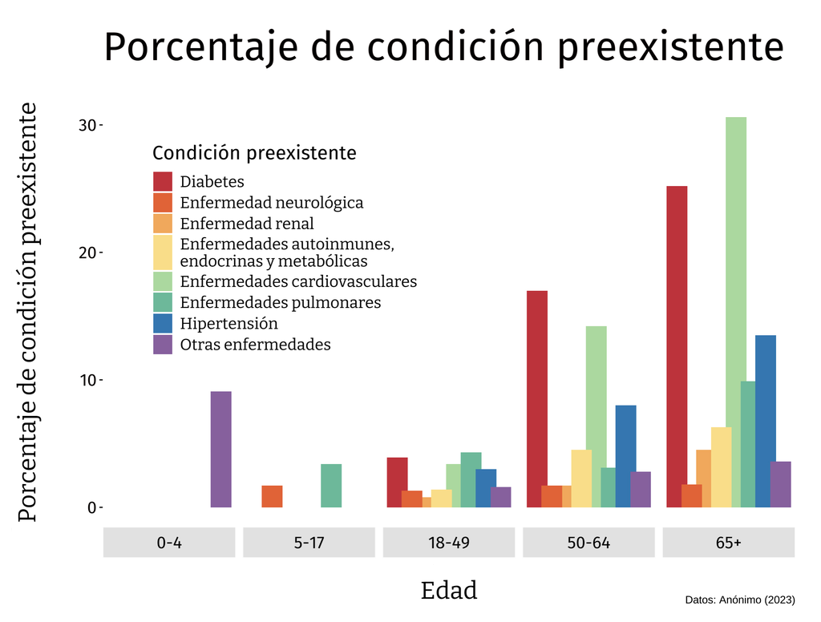

### Gráfico de barras con ggplot2

code

analysis

Esta vez se tiene un gráfico de barras “ggplot2” con paleta de colores manual.

Sep 22, 2024

FV

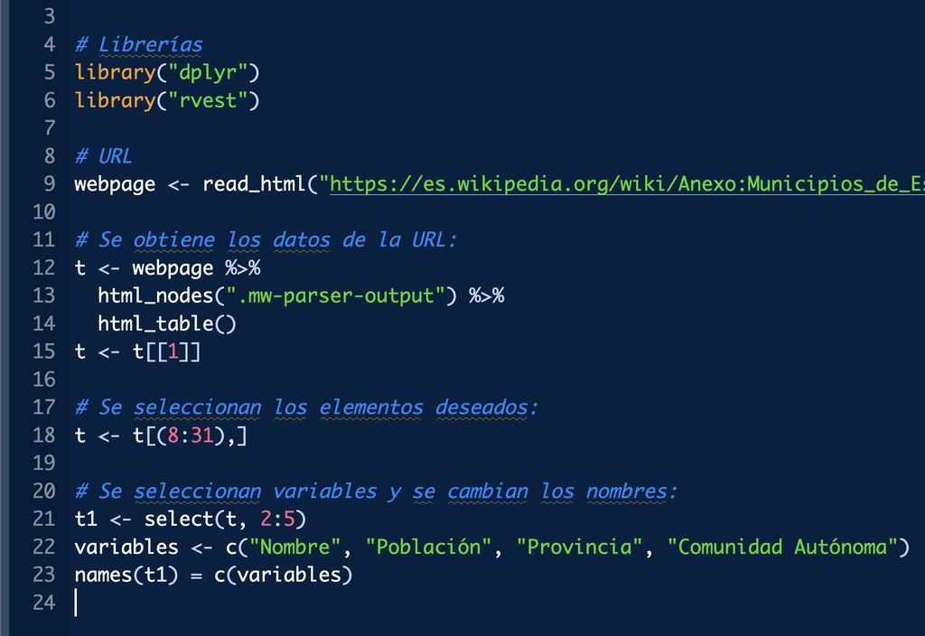

### Web Scraping con rvest

code

analysis

Esta vez se trabaja con el paquete ”rvest” y la intención es obtener un marco de datos de Wikipedia.

Sep 22, 2024

FV

[figure not shown]

### Vinos 2021, análisis descriptivo

code

analysis

El objetivo es extraer información útil a partir de un análisis estadístico para este marco de datos.

Jun 3, 2024

FV

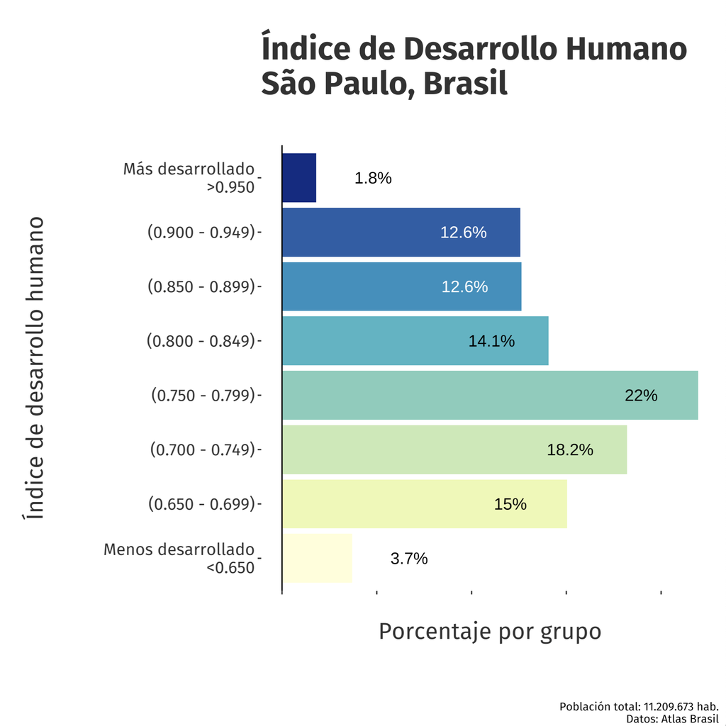

### Gráfico de barras horizontales con ggplot2 🇧🇷

code

analysis

Los datos representan el Índice de Desarrollo Humano en los diferentes distritos del Municipio de São Paulo en el 2010.

Jun 2, 2024

FV

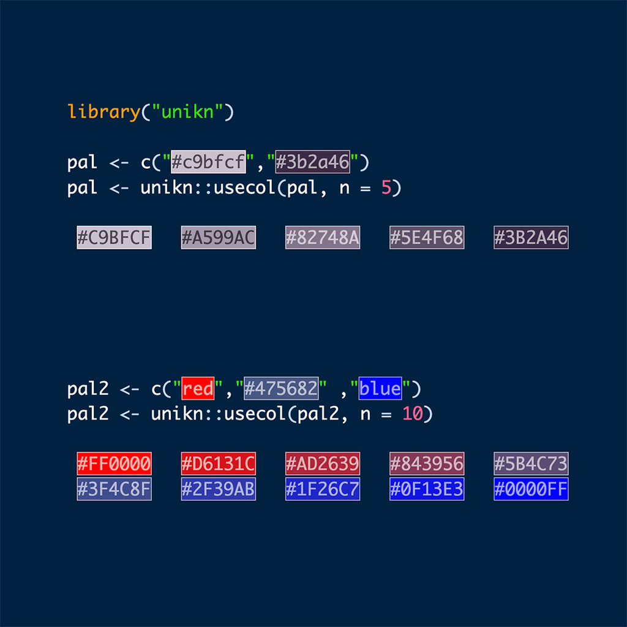

### Generar n colores con ayuda de la librería unikn

code

analysis

tips

May 31, 2024

FV

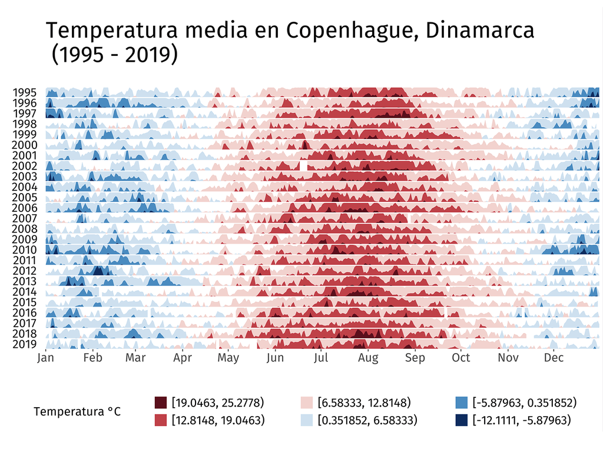

### Temperatura media en Copenhague, Dinamarca

code

analysis

Datos: climate_CPH (1995-2019)

May 26, 2024

FV

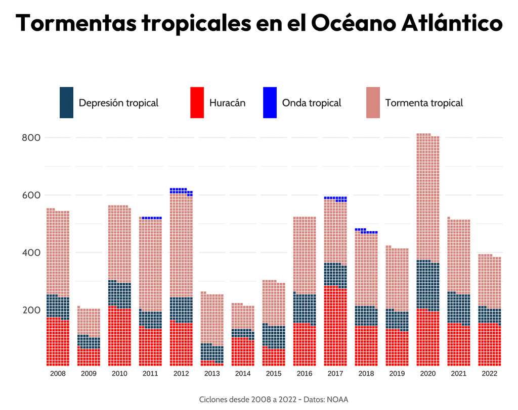

### Tormentas tropicales en el Océano Atlántico

code

analysis

Ciclones desde 2008 a 2022 - Datos: NOAA

May 18, 2024

FV

[figure not shown]

### Puntuación por taza de café (CQI)

code

analysis

Author: FV

Nov 21, 2023

FV

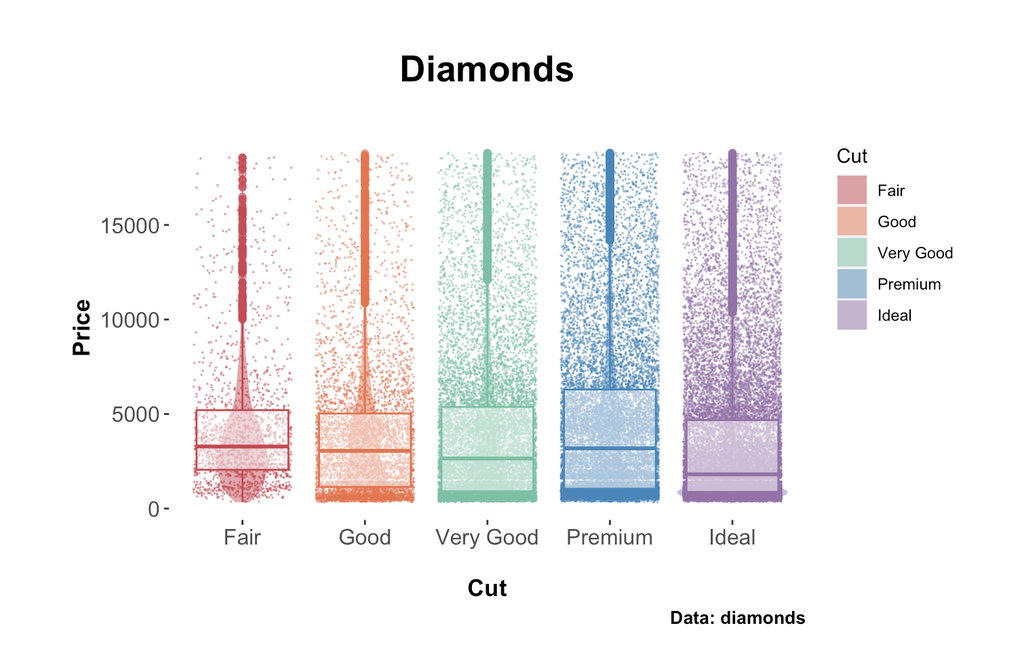

### Boxplot (data:diamonds)

code

analysis

This time we work with diamond data. It generates a diagram of box with “ggplot2”, with various details in the chart that allow better perceive the distribution of data.

May 27, 2023

FV

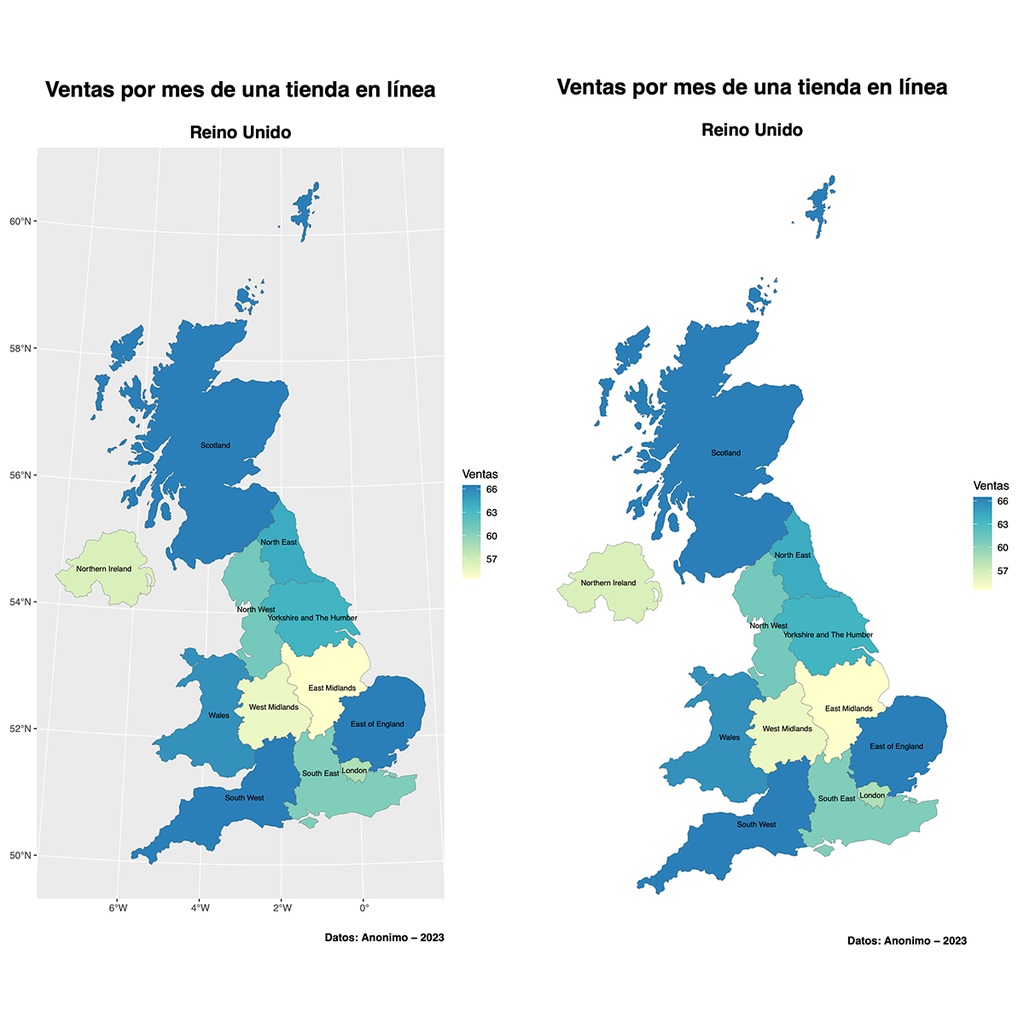

### Monthly sales of an online shop in the UK 🇬🇧

code

map

Map of the United Kingdom drawn from a shapefile layer. This is a post with executable code.

May 1, 2023

FV

[figure not shown]

### World’s tallest towers (Top 6)

code

analysis

World’s tallest towers (Top 6)

Mar 13, 2023

FV

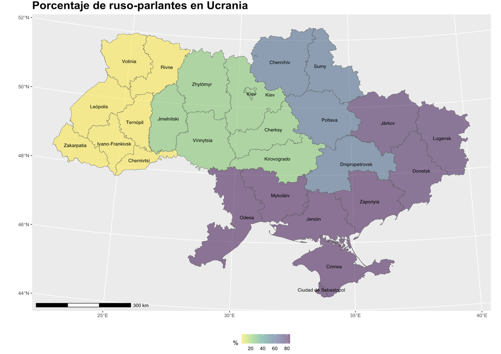

### Percentage of Russian speakers in Ukraine 🇺🇦

code

analysis

map

Working with the libraries: “sf”, “stringr”, “dplyr”, “ggplot2” and “ggthemes”. 🇺🇦

Jan 11, 2023

FV

[figure not shown]

### Winning the 2022 World Cup (Top 10 favourites)

code

analysis

Winning the 2022 World Cup

Dec 1, 2022

FV

[figure not shown]

### ggplot2 🇨🇭

code

analysis

Qualification of a university student in their last 7 semesters. 🇨🇭

Apr 27, 2022

FV

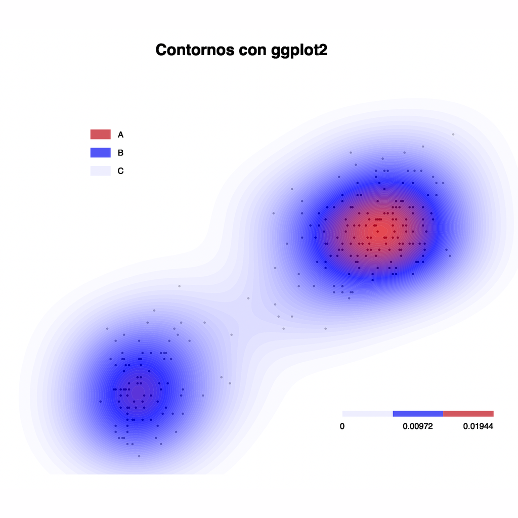

### Contours with ggplot2

code

This is a post with executable code.

Apr 21, 2022

FV

[figure not shown]

### CO2 emissions, GDP per capita and population by country - 2020

code

analysis

This is a post with executable code.

Mar 28, 2022

FV